# A. Highlight Challenge

1. Analisis Deskripsi kondisi pandemi terhadap sektor swasta, pemerintah (transportasi, pariwisata, dsb), dan sosial ekonomi
2. Rekomendasi dan saran terhadap kebijakan pemerintah untuk menyelamatkan sektor kritikal terdampak pandemi
3. Rekomendasi value bisnis terhadap sektor swasta dan pemerintah untuk bertahan dan membuka peluang baru

# B. Highlight Dataset

### Coverage Area

- DKI Jakarta

### Topik Dataset:

- Kesehatan
- Transportasi
- Sosial Ekonomi
- Pariwisata

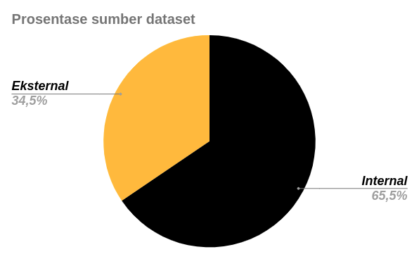

Daftar sitasi lengkap sumber dataset: [Sumber Data](https://docs.google.com/spreadsheets/d/1ilxNf37yFyXJZm5puQ8GbRXJ4B9MVlDu_JVkRrz99EA/edit?usp=sharing) ⬅️🔴🔴🔴

## 1. Exploratory Data Analysis (Analisis Deskripsi)

- Using Agregated Data to get insight and hypothesis before analysis
- Point of View
- Analisis

### a. Using Agregated Data to get insight and hypothesis before analysis

#### Kondisi kesehatan | Sumber data: Internal + Eksternal

- Grafik Harian Kasus baru COVID-19 DKI Jakarta

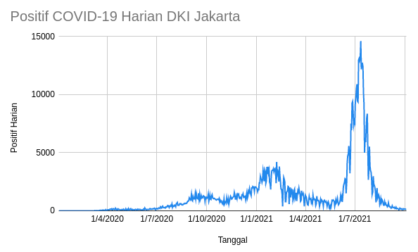

- Perkembangan total penerimaan dosis Vaksin pertama dan kedua

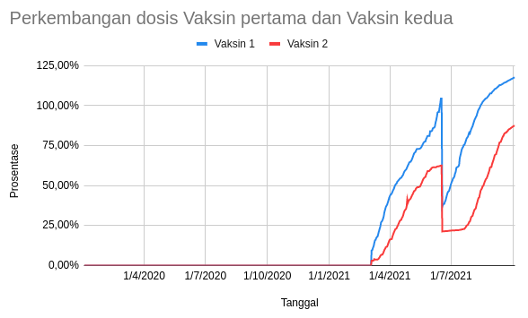

#### Kondisi ekonomi | Sumber data: Eksternal

- Indeks Kepercayaan konsumen  
  Indikator kepercayaan konsumen ini memberikan indikasi perkembangan konsumsi dan tabungan rumah tangga di masa depan, berdasarkan jawaban mengenai situasi keuangan yang diharapkan, sentimen mereka tentang situasi ekonomi secara umum, pengangguran dan kemampuan tabungan. Indikator di atas 100 menandakan peningkatan kepercayaan konsumen terhadap situasi ekonomi masa depan, sebagai akibatnya mereka cenderung tidak menabung, dan lebih cenderung menghabiskan uang untuk pembelian besar dalam 12 bulan ke depan. Nilai di bawah 100 menunjukkan sikap pesimistis terhadap perkembangan ekonomi di masa depan, yang mungkin mengakibatkan kecenderungan untuk menabung lebih banyak dan mengurangi konsumsi (OECD Data, 2021).  
  https://data.oecd.org/leadind/consumer-confidence-index-cci.htm
- Grafik Bulanan Indeks kepercayaan konsumen DKI Jakarta

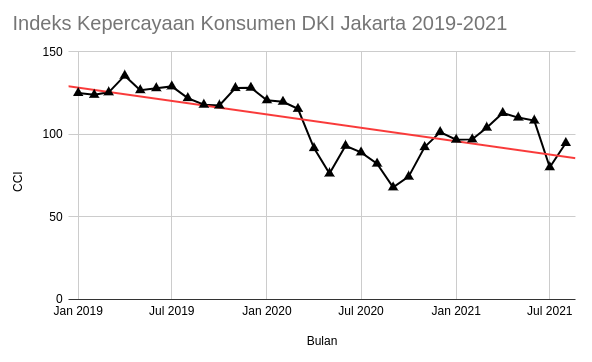

### b. Point of View

⭐⭐⭐

#### b.1. Insight

- Kasus baru COVID-19 melonjak tajam pada pertengahan tahun 2020, awal tahun 2021 dan pertengahan tahun 2021
- Penurunan kasus baru mulai terjadi sejalan dengan meningkatnya total persentase vaksinasi COVID-19 dosis pertama dan dosis kedua
- Indeks Kepercayaan Konsumen memiliki tren yang terlihat serupa dengan jumlah kasus baru COVID-19 pada pertengahan tahun 2020, awal tahun 2021 dan pertengahan tahun 2021 yang terlihat memburuk yaitu nilai indeks berada dibawah 100
- **Dengan menjadikan data kasus harian dan vaksinasi sebagai representasi kondisi pandemi dari sisi kesehatan dan data indeks kepercayaan konsumen sebagai representasi data kondisi pandemi dari sisi ekonomi, konteks permasalahan yang penting untuk dianalisis adalah bagaimana meningkatkan value bisnis dari sisi ekonomi dengan tetap mempertimbangkan aspek kesehatan secara fair menggunakan Descriptive Analytics maupun Statistical Inference dan Machine Learning**.

#### b.2. North Star Metric

## "Bagaimana rekomendasi dan saran untuk mempertahankan atau bahkan memulihkan beberapa sektor ekonomi dengan tetap mempertimbangkan aspek kesehatan untuk saat ini maupun kedepannya?"

#### b.3. Approach

- Kenapa sektor ekonomi menjadi penting untuk dianalisis?
  - Karena sektor ekonomi merupakan sektor yang melingkupi hajat hidup banyak orang meliputi institusi formal, pariwisata, dan sosial.
- Kenapa mempertimbangkan aspek kesehatan(COVID-19)?
  - Karena concern utama saat ini sebenarnya adalah bagaimana menekan kasus COVID-19 dengan tidak menggunakan solusi dari aspek kesehatan saja sebagai solusi tunggal, namun dalam kasus ini aspek ekonomi terdampak perlu dipertimbangkan dan begitupun sebaliknya.
- Apa yang dimaksud mempertahankan atau bahkan memulihkan beberapa sektor ekonomi?
  - Solusi tunggal bukanlah rekomendasi yang bijak saat ini, konteks mempertahankan sektor ekonomi adalah bagaimana keberlangsungan supply dan demand tetap berjalan pada skala minimum untuk menjaga nafas perekonomian sembari menunggu situasi kesehatan mencapai kondisi yang lebih aman.
- Apa yang dimaksud waktu saat ini maupun kedepannya?
  - Dari data yang kita miliki, hingga saat ini kasus baru COVID-19 mengalami penurunan dan dilihat dari Indeks kepercayaan konsumen per Agustus 2021, terlihat tren meningkat dari 80,1 menjadi 94,8 yang diperkirakan akan terus meningkat seiring dengan menurunnya kasus baru COVID-19 dan bertambahnya persentase vaksinasi. Namun kita perlu mengantisipasi kondisi tidak pasti di masa depan. Apabila terjadi kembali perburukan dari sisi kesehatan yang akan berdampak pada ekonomi, solusi baru yang bisa kita hadirkan perlu dipertimbangkan kembali dengan menggunakan data yang ada.

### c. Analisis

- Uji Hipotesis H0: Angka positif bulanan tidak memiliki korelasi yang kuat dengan IKK
- Analisis Deskriptif Tingkat Pengangguran Terbuka
- Analisis Deskriptif Kerugian akibat Pandemi pada Moda Transportasi Umum milik BUMD DKI Jakarta(MRT, LRT, dan Transjakarta)
- Analisis Deskriptif Kerugian akibat Pandemi pada Kapal Cepat milik Swasta, Koperasi, dan Dishub DKI Jakarta di Kepulauan Seribu

```python
# import library data processing
import pandas as pd
import numpy as np

# import library for visualize
import matplotlib.pyplot as plt
import seaborn as sns

# import self module
from prepare_load import *

# import ML library
from sklearn.linear_model import LinearRegression
from sklearn.linear_model import LogisticRegression
from sklearn.model_selection import train_test_split
from statsmodels.formula.api import ols
```

```python
# path dataset
path_main = "dat_filtered/"
df_filter = "dfilter-2019-2021.xlsx"
mobilty_goole_path = "2020_ID_Region_Mobility_Report.csv"
df_kapal_pelabuhan = "dataframe_pivot_pelabuhan_v2.xlsx"
tj_compare = "Jumlah Penumpang dan Pendapatan Trans Jakarta menurut Koridor_Rute.xlsx"

sheet_cci = "cci_DKI_2"
sheet_hipo = "hipo"
sheet_daily_cvd = "cvd_daily_dki"
sheet_montly = "dff_ini"
sheet_tpt_year = "tpt_only"

# load dataset
df_month = pd.read_excel(path_main+df_filter, sheet_name=sheet_montly)
df_hipo = pd.read_excel(path_main+df_filter, sheet_name=sheet_hipo)
df_mobility = pd.read_csv(path_main+mobilty_goole_path)
tj_compare = pd.read_excel(path_main+tj_compare)
df_tpt = pd.read_excel(path_main+df_filter, sheet_name=sheet_tpt_year)
df_cvd_daily = pd.read_excel(path_main+df_filter, sheet_name=sheet_daily_cvd)
```

### c.1. Uji HIpotesis

```python
df_hipo = df_hipo[["Positif_Bulanan", "CCI"]]
df_hipo = df_hipo.dropna()
fastDescribe(df_hipo)
```

```
##################### Shape ###################
(32, 2)

##################### Types ###################
Positif_Bulanan      int64
CCI                float64
dtype: object

##################### Head ####################
   Positif_Bulanan    CCI
0                0  125.1
1                0  124.0
2                0  125.5

##################### Tail ####################
    Positif_Bulanan    CCI
29           113409  108.4
30           271185   80.1
31            35930   94.8

##################### NA #####################
Positif_Bulanan    0
CCI                0
dtype: int64

##################### Describe ################
       Positif_Bulanan         CCI
count        32.000000   32.000000
mean      26580.718750  107.403125
std       52715.906664   18.960408
min           0.000000   67.900000
25%           0.000000   92.900000
50%        3265.500000  111.600000
75%       31962.750000  124.275000
max      271185.000000  135.600000
```

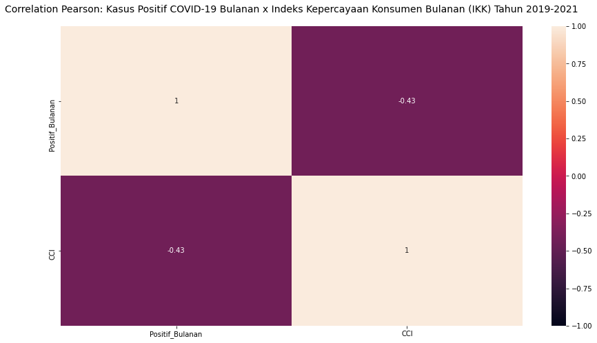

```python
# visualize correlation pearson

plt.figure(figsize=(15, 8))

heatmap = sns.heatmap(df_hipo.corr(method="pearson"), vmin=-1, vmax=1, annot=True)

heatmap.set_title('Correlation Pearson: Kasus Positif COVID-19 Bulanan x Indeks Kepercayaan Konsumen Bulanan (IKK) Tahun 2019-2021', fontdict={'fontsize':14}, pad=20);
```

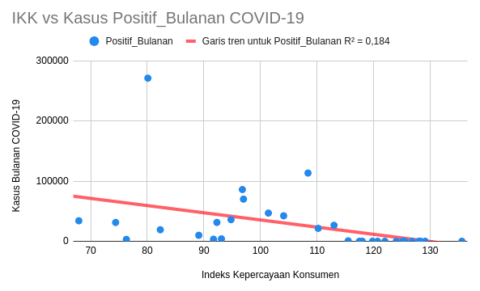

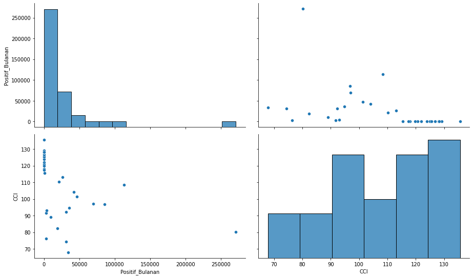

```python
g = sns.pairplot(df_hipo,kind='scatter')
g.fig.set_size_inches(15,8)
plt.show()
```

#### Pearson Correlation Equation:

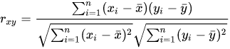

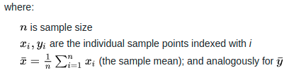

```python
# check confidence of correlation
print("Check confidence of correlation")
model = ols("Positif_Bulanan ~ CCI", data=df_hipo).fit()
print(model.summary())
```

```
Check confidence of correlation
                            OLS Regression Results
==============================================================================
Dep. Variable:        Positif_Bulanan   R-squared:                       0.184
Model:                            OLS   Adj. R-squared:                  0.157
Method:                 Least Squares   F-statistic:                     6.786
Date:                Mon, 11 Oct 2021   Prob (F-statistic):             0.0142
Time:                        16:25:31   Log-Likelihood:                -389.56
No. Observations:                  32   AIC:                             783.1
Df Residuals:                      30   BIC:                             786.1
Df Model:                           1
Covariance Type:            nonrobust
==============================================================================
                 coef    std err          t      P>|t|      [0.025      0.975]
------------------------------------------------------------------------------
Intercept   1.548e+05      5e+04      3.098      0.004    5.28e+04    2.57e+05
CCI        -1194.1672    458.407     -2.605      0.014   -2130.360    -257.975
==============================================================================
Omnibus:                       45.082   Durbin-Watson:                   1.081
Prob(Omnibus):                  0.000   Jarque-Bera (JB):              199.495
Skew:                           2.964   Prob(JB):                     4.79e-44
Kurtosis:                      13.700   Cond. No.                         637.
==============================================================================

Notes:
[1] Standard Errors assume that the covariance matrix of the errors is correctly specified.
```